# Practica 4

J. Rojas, X. Díaz

3/7/2022

# Repository

Git hub project: https://github.com/XochitlDiaz/BioifoII_pubrep

#### Save R history

history(max.show = Inf, reverse = T)

# Cluster Usage

```r
module load kallisto/0.45.0
module load sra/2.9.6-1
module load r/4.0.2
```

# Data Description

Data was obtained by using the sra package and the respective accesion list found in it’s GEO Dataset. Our SRA Accession is: GSE185492. This was found by running a search in th NCBI Databse and then sending the selected files to the SRA Run Selector to generate an accession list.

The data itself was generated by RNA-seq of control and treated mice. The goal of this study was to the investigate the hepatic effects of lactational deliver of Triclosan in neonatal mice. The treatment group was Triclosan treated mice via milk ingest and it’s respective control group (N=3/group).

In this study, DE analysis was performed to identify the transcriptomic profile of the control and treatment group.

## Data Download

### Commands

```
scp <storage_dir>/SRR_Acc_List.txt crojas@dna.lavis.unam.mx:´<cluster_dir>/SRR_Acc_List.txt
xargs fastq-dump <SRR_Acc_List.txt
scp <storage_dir>/SraRunTable.txt crojas@dna.lavis.unam.mx:´<cluster_dir>/SraRunTable.txt
```

### Explanation

To download the data, we first generated an accesion list containing only the replicas used in this report. The aforementioned accesion list was then uploaded to our server using the scp command. Finally, to download all the files contained in the accession list, the fastq-dump command was used. To run the command for every file contained in our accession list, the expression: “<SRR_Acc_List.txt” was employed. We also downloaded the associated metadata, since it will come in handy both for understanding the treatment status of each sample and to tag each simple in our differential expression analysis.

# RNA-seq Pipeline

## Quality Control

After checking the metadata and data description of our reads, we realized that they had already been filtered and set to the same length. Therefore, it was no longer necessary to perform any clipping or filtering.

## Indexing

### Download Reference Transcriptome

### Commands

```r
wget https://ftp.ebi.ac.uk/pub/databases/gencode/Gencode_mouse/release_M29/gencode.vM29.transcripts.fa.gz
```

### Explanation

The wget command allows us to download a file by providing the file URL from a public available server. We downloaded the full Mouse transcriptome from the GENCODE webpage.

## Kallisto Indexing

### Commands

```r
kallisto index -i index_gencode_v39_transcripts gencode.v39.transcripts.fa.gz
```

### Explanation

This command helps us index our transcriptome reference file. The -i parameter is used to determine the output of our indexed transcriptome. This will allow us to perform kallisto quantification much faster and efficiently.

## Quantification

### Commands

```r
awk 'BEGIN { t=0.0;sq=0.0; n=0;} ;NR%4==2 {n++;L=length($0);t+=L;sq+=L*L;}END{m=t/n;printf("total %d avg=%f stddev=%f\n",n,m,sq/n-m*m);}' SRR18735738.fastq
awk 'BEGIN { t=0.0;sq=0.0; n=0;} ;NR%4==2 {n++;L=length($0);t+=L;sq+=L*L;}END{m=t/n;printf("total %d avg=%f stddev=%f\n",n,m,sq/n-m*m);}' SRR18735739.fastq
awk 'BEGIN { t=0.0;sq=0.0; n=0;} ;NR%4==2 {n++;L=length($0);t+=L;sq+=L*L;}END{m=t/n;printf("total %d avg=%f stddev=%f\n",n,m,sq/n-m*m);}' SRR18735740.fastq
awk 'BEGIN { t=0.0;sq=0.0; n=0;} ;NR%4==2 {n++;L=length($0);t+=L;sq+=L*L;}END{m=t/n;printf("total %d avg=%f stddev=%f\n",n,m,sq/n-m*m);}' SRR18735741.fastq
awk 'BEGIN { t=0.0;sq=0.0; n=0;} ;NR%4==2 {n++;L=length($0);t+=L;sq+=L*L;}END{m=t/n;printf("total %d avg=%f stddev=%f\n",n,m,sq/n-m*m);}' SRR18735742.fastq
awk 'BEGIN { t=0.0;sq=0.0; n=0;} ;NR%4==2 {n++;L=length($0);t+=L;sq+=L*L;}END{m=t/n;printf("total %d avg=%f stddev=%f\n",n,m,sq/n-m*m);}' SRR18735743.fastq
```

### Explanation

Since our data is presented as single-read ends, we must specify the average length and standard deviation for each of our sequenced group of reads. To do this we used the regular awk command to obtain the aforementioned information. Then we used this output to run quantification with kallisto.

### Commands

```r
mkdir <each sample name>
kallisto quant -i /mnt/Timina/bioinfoII/crojas/RNA/gencode_index -o ./SRR18735738 ../sra/SRR18735738.fastq --single -l 100.00000 -s 0.00001
kallisto quant -i /mnt/Timina/bioinfoII/crojas/RNA/gencode_index -o ./SRR18735739 ../sra/SRR18735739.fastq --single -l 100.00000 -s 0.00001
kallisto quant -i /mnt/Timina/bioinfoII/crojas/RNA/gencode_index -o ./SRR18735740 ../sra/SRR18735740.fastq --single -l 100.00000 -s 0.00001
kallisto quant -i /mnt/Timina/bioinfoII/crojas/RNA/gencode_index -o ./SRR18735741 ../sra/SRR18735741.fastq --single -l 100.00000 -s 0.00001
kallisto quant -i /mnt/Timina/bioinfoII/crojas/RNA/gencode_index -o ./SRR18735742 ../sra/SRR18735742.fastq --single -l 100.00000 -s 0.00001
kallisto quant -i /mnt/Timina/bioinfoII/crojas/RNA/gencode_index -o ./SRR18735743 ../sra/SRR18735743.fastq --single -l 100.00000 -s 0.00001
```

### Explanation

Since kallisto quant command produces its output into directories for each of the test file’s name, first we created directories to fit this requirement, then we ran the specified commands in an sge file.

The parameter (-i) in kallisto quant is used to specify the route and name of our index files.  
The -o parameter is used to specify the output directory for each of the fastq files being quantified. Since these are single end reads, we must specify this with the flag “–single”. The -l and -s parameters are used to specify mean fragment length and standard deviation for each file. Finally, we provide the command with each of the files we will quantify.

## Normalization

### Batch effect correction

Since all of the samples were sequenced in the same batch, there shouldn’t be any bias driven by variation in the sequencing batches. Therefore, it was not necessary to undergo batch effect correction.

### DESeq2

Because we want to make differential expression analysis through RNA composition comparison between the samples of the experiment, we used DESeq2’s normalization, given that it is an appropriate method for the data we are using.

### Commands

```r
cd /mnt/Timina/bioinfoII/XJS/Yalbi/kallisto
module load r/4.0.2
R

(In R)
library(tximport)
library(tidyverse)
files <- file.path("/mnt/Timina/bioinfoII/XJS/Yalbi/kallisto", list.dirs(), "abundance.h5")
names(files) <- str_extract(files,"SRR\\d+")
files = files[2:7]

# Load table with trx id and gene id corrspondence
tx2gene <- read.csv("/mnt/Timina/bioinfoII/rnaseq/resources/gencode/gencode.vM28.basic.trx_id-gene_id-no_ver.tsv",stringsAsFactors = F)
# Load table with trx id and gene name correspondence
tx2genename <- read.csv("/mnt/Timina/bioinfoII/rnaseq/resources/gencode/gencode.vM28.basic.trx_id-gene_name-no_ver.tsv",stringsAsFactors = F)

txi.kallisto <- tximport(files, type = "kallisto", tx2gene = tx2gene, ignoreAfterBar=TRUE, ignoreTxVersion=TRUE)
txi.kallisto.name <- tximport(files, type = "kallisto", tx2gene = tx2genename, ignoreAfterBar=TRUE, ignoreTxVersion=TRUE)

> library(DESeq2)
samples <- read.csv("/mnt/Timina/bioinfoII/XJS/Yalbi/SraRunTable.txt",stringsAsFactors = F, header = TRUE)
samples <- column_to_rownames(samples, var = "Run")

dds <- DESeqDataSetFromTximport(txi.kallisto,colData = samples,design = ~ treatment)

keep <- rowSums(counts(dds)) >= 6
dds <- dds[keep, ]
dds$treatment <- factor(dds$treatment, levels = c("TCS breastmilk","Regular breastmilk"))
dds <- DESeq(dds)
res <- results(dds)
```

### Explanation

First we loaded R 4.0.2 in our working environment, then we opened R form the cluster terminal to run the code shown above. It is important to mention that to run the code we generated the R working environment at the working directory where we saved the output of kallisto quantification.

To integrate the metadata of our samples in order to make indicate sample groups (condition groups) we loaded the metadata file onto our R environment and then extracted the appropiate columns that associate treatment group with sample name.

## Reducing significant DE genes

### Commands

```r
de <- as.data.frame(res)
de$diffexpressed <- "NO"
de$diffexpressed[de$log2FoldChange > 1 & de$pvalue < 0.01] <- "UP"
de$diffexpressed[de$log2FoldChange < -1 & de$pvalue < 0.01] <- "DOWN"

library(ggrepel)
de$names <- NA
filter <- which(de$diffexpressed != "NO" & de$padj < 0.01 & (de$log2FoldChange > 1 | de$log2FoldChange < -1)) #<<
de$names[filter] <- rownames(de)[filter] #<<

res.05 <- results(dds, alpha = 0.05)
table(res.05$padj < 0.05)

resLFC1 <- results(dds, lfcThreshold=1)
table(resLFC1$padj < 0.1)
```

### Explanation

Since the DE Analysis produced a large collection of differentially expressed genes, we decided to narrow our search in order to find a more informative subset of genes. To do this, we added another column in our matrix to classify genes according to whether we consider them as differentially expressed or not. Then, we conducted filtering in two ways:

1. By assesing log fold change
- We set our new filtered selection to admit genes with a higher absolute value than 1
2. By setting a lower adjusted p-value threshold
- Genes with an adj. p-value lower than 0.05
- Genes with an adj. p-value lower than 0.01 (This became our final collection)

Once we had these subsets, we realized that the 0.01 p-value gave the most direct and concrete results, but we also decided to produce results for other differentialy expressed genes without such a strict p-value threshold.

# Results

## Volcano plot

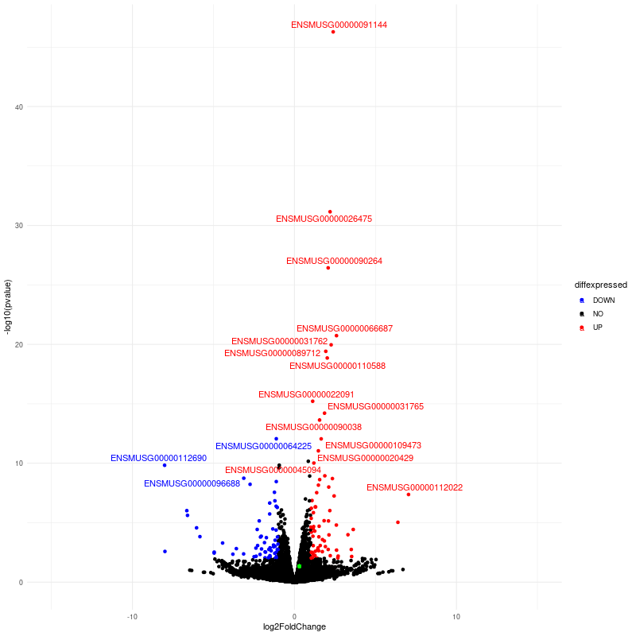

Shows the overall differentially expressed genes by comparing the TCS to regular breastmilk.

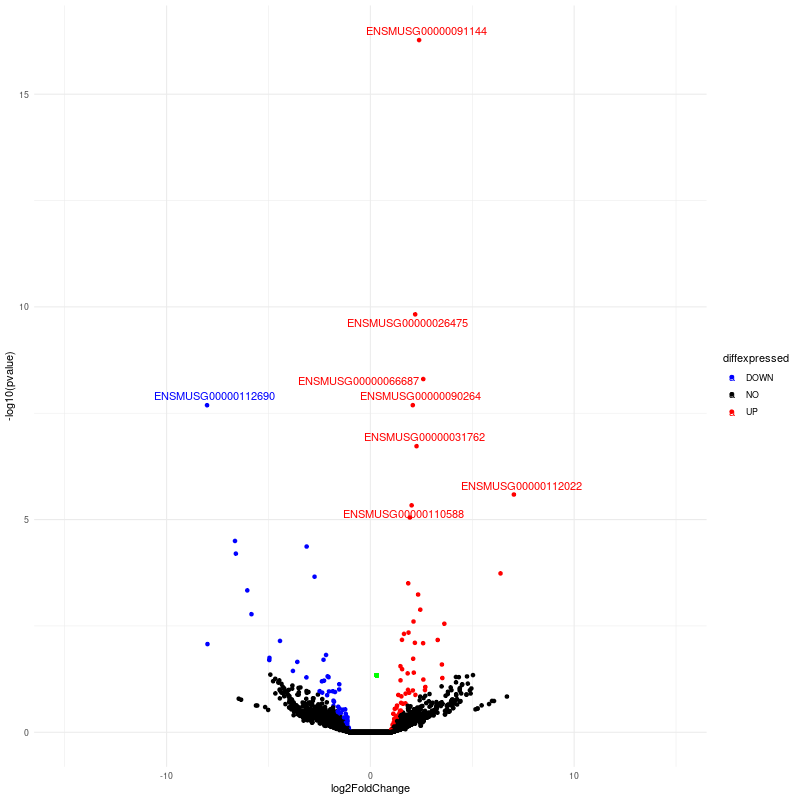

#### Code

```r
# Generate and save normal plot
#save plot as png
outdir = "/mnt/Timina/bioinfoII/XJS/Yalbi/kallisto/Results"
png(file = paste0(outdir,"volcano_filter.png"), width = 800, height = 800)
ggplot(data=de, aes(x=log2FoldChange, y=-log10(pvalue), col=diffexpressed, label=names)) + #<<
    geom_point() +
  geom_point(x=0.305969,y=1.337297875,col="green") +
    scale_color_manual(values=c("blue", "black", "red")) + #change dot colour #<<
    theme_minimal() +
    geom_text_repel() + #<<
    xlim(-15,15)

dev.off()
```

#### Filtered plot

```r
png(file = paste0(outdir,"volcano_filt.png"),
    width = 800, height = 800)
ggplot(data=deLFC1, aes(x=log2FoldChange, y=-log10(pvalue), col=diffexpressed, label=names)) + #<<
    geom_point() +
  geom_point(x=0.305969,y=1.337297875,col="green") +
    scale_color_manual(values=c("blue", "black", "red")) + #change dot colour #<<
    theme_minimal() +
    geom_text_repel() + #<<
    xlim(-15,15)

dev.off()
```

## Functional Analysis

We used Gprofilter to make a gene ontology enrichment analysis to assess whether the results of our differential expression analysis made sense or not.

#### Code

```r
library(ggrepel)


library(gprofiler2)
resSig <- subset(res, padj < 0.1 & log2FoldChange > 1)
resSig <- resSig[ order(resSig$log2FoldChange, decreasing = TRUE), ]
DEG <- rownames(resSig)
genes_universe <- rownames(dds)

# enrichment analysis
gostres = gost(query = DEG, organism = "mmusculus", significant = T,
               correction_method = "fdr", domain_scope = "custom",
               custom_bg = genes_universe, ordered_query = TRUE)
names(gostres)
attributes(gostres$meta)
head(gostres$result)


library(forcats)
outdir = "/mnt/Timina/bioinfoII/XJS/Yalbi/kallisto/Results/"
go <- as.data.frame(gostres$result)

png(file = paste0(outdir,"gost01-resSig.png"),
    width = 800, height = 800) # guardar el plot en formato png
# Reorder following the value of another column:
library(ggplot2)
library(dplyr)
go %>%
  dplyr::slice(1:20) %>%
  select(p_value, term_name) %>%
  mutate(go = fct_reorder(term_name, p_value)) %>%
  ggplot( aes(x=go, y=p_value)) +
    geom_bar(stat="identity", fill="#3A68AE", alpha=.6, width=.4) +
    coord_flip() +
    labs(x = "", y = "Adjusted P-value") +
    theme_bw(base_size = 20)

dev.off()
```

[output not shown]

# References

- Geo Dataset: https://www.ncbi.nlm.nih.gov/geo/query/acc.cgi?acc=GSE185492
- SRA Run Selector: https://www.ncbi.nlm.nih.gov/Traces/study/?acc=PRJNA826106&o=acc_s%3Aa

Ref1: Mónica Padilla 2022, *RNA-seq Bioinformática - LCG-EJ*, Git Hub, viewed 10 March 2022, https://github.com/mpadilla905/clase_RNA-seq_LCGEJ2022.git

Ref2: EnsEMBL, *Gene: Phf11c ENSMUSG00000091144*, EnsEMBL Core, https://www.ensembl.org/Mus_musculus/Gene/Splice?db=core;g=ENSMUSG00000091144;r=14:59618282-59632830;t=ENSMUST00000166912

Ref3: Pacher Lab, *Kallisto -Maual*, Pacher Lab, https://pachterlab.github.io/kallisto/manual

Ref4: USADELLAB, *Trimmomatic: A flexible read trimming tool for Illumina NGS data*, USADELLAB ORG, http://www.usadellab.org/cms/?page=trimmomatic

Ref5: MultiQC, *Using MultiQC*, MultiQC Docs, https://multiqc.info/docs/

Ref6: Bioconductor, *Package ‘tximport’*, Bioconductor, https://bioconductor.org/packages/devel/bioc/manuals/tximport/man/tximport.pdf

Ref7: Documentation, *MultiQC*, https://multiqc.info/docs/

Ref8: SRA-documentation, *Prefetch to local files*, https://github.com/ncbi/sra-tools/issues/71